# Technology and Social Change

Lecture 17: Final Thoughts

Bogdan G. Popescu

bgpopescu@tec.mx

Tecnológico de Monterrey

# One Course, One Question

## The Question We Kept Asking

We covered 12,000 years in one semester — from grain silos to large language models.

Underneath every lecture was a single question:

> **Why does the same technology enrich and liberate some societies — and impoverish or trap others?**

Wheat, the printing press, the steam engine, robots, AI: the technology changes, the question does not.

Today: no new material. Just the answer — in five ideas, told through the most memorable slides of the course.

## Five Ideas to Take With You

1. **Technology is not destiny** — institutions decide what it does.
2. **Every technology redistributes power** — and the losers fight back.
3. **Rising productivity does not mean rising wages** — who captures the gains is decided by bargaining power and politics.
4. **Inventions appear where they pay, not where people are smartest** — and since each one is built from earlier ones, innovation accelerates.
5. **You cannot predict the future — but you can analyze it.**

*If you remember these five sentences in ten years, this course did its job.*

# Idea 1 — Technology Is Not Destiny

*The same machine, opposite outcomes — institutions decide which.*

## The Best Puzzle in the Course

### Lecture 5

From 1450, the movable-type press spread across Europe and the Islamic world.

- **Same machine**. Same basic inputs. Same potential.

Yet the outcomes diverged radically:

- **Dutch Republic**: presses multiplied freely, book prices collapsed
- **England**: printing fueled a scientific revolution
- **Ottoman Empire**: Arabic-script printing banned for **nearly 300 years**

**Why did identical technology produce such different outcomes?**

[figure not shown]

A page from the Gutenberg Bible (c. 1455), the first major book printed with movable type. Photo: NYC Wanderer / Wikimedia Commons (CC BY-SA 2.0).

### Lecture 5

| Indicator | Ottoman Empire | Western Europe |
| --- | --- | --- |
| First Arabic-script press | 1729 | 1450s |
| Books published by 1800 | ~500 titles | Millions of titles |
| Literacy rate (c. 1800) | ~2–3% | 30–60% (varies) |
| Universities (c. 1800) | Madrasas (static curriculum) | Research universities emerging |

**The calculus**: the losers (scribal guilds, the *ulema*) were organized, powerful, and inside the palace. The winners were diffuse and outside it.

**And the evidence is causal** — Rubin (2014):

- The press predicted Protestant adoption *only* where authorities didn’t block it
- Technology is necessary but not sufficient
- **Institutions are the binding constraint**

## The Same Puzzle, 570 Years Later: Robots

### Lecture 11

```
%%{init: {'theme': 'base', 'themeVariables': {'fontSize': '18px', 'primaryColor': '#4a7c6f', 'primaryTextColor': '#1e293b', 'primaryBorderColor': '#334155', 'lineColor': '#64748b', 'secondaryColor': '#f9fafb', 'tertiaryColor': '#f9fafb'}, 'flowchart': {'useMaxWidth': true, 'nodeSpacing': 30, 'rankSp…
flowchart TD
    A["Industrial Robots<br/>(Same Technology)"] --> B["Germany"]
    A --> C["United States"]
    A --> D["Sweden"]
    B --> E["Strong unions<br/>Vocational ed<br/>Codetermination"]
    C --> F["Weak unions<br/>Limited training<br/>Market-led"]
    D --> G["Strong unions<br/>Active labor<br/>market policy"]
    E --> H["Moderate inequality<br/>Job security"]
    F --> I["Sharp inequality<br/>Job loss"]
    G --> J["Low inequality<br/>Smooth transitions"]
    style A fill:#1e293b,color:#f9f9fb,stroke:#334155
    style H fill:#b7943a,color:#1e293b,stroke:#334155
    style I fill:#b44527,color:#f9fafb,stroke:#334155
    style J fill:#4a7c6f,color:#f9fafb,stroke:#334155
```

# Idea 2 — Every Technology Redistributes Power

*…and the losers always fight back.*

## The Original Case: The Agricultural Paradox

### Lectures 1 & 4

> “Did we domesticate wheat, or did wheat domesticate us?” — Harari (2015)

**Gained**

- More total food
- Larger populations
- Permanent settlements
- Occupational specialization

**Lost**

- Longer work hours
- Worse nutrition (less diverse)
- New diseases (density)
- Social inequality

**Paradox**: Agriculture spread despite making most lives harder. So *someone* must have gained. Who?

## The Evidence Is Written in Our Bones

### Lecture 3

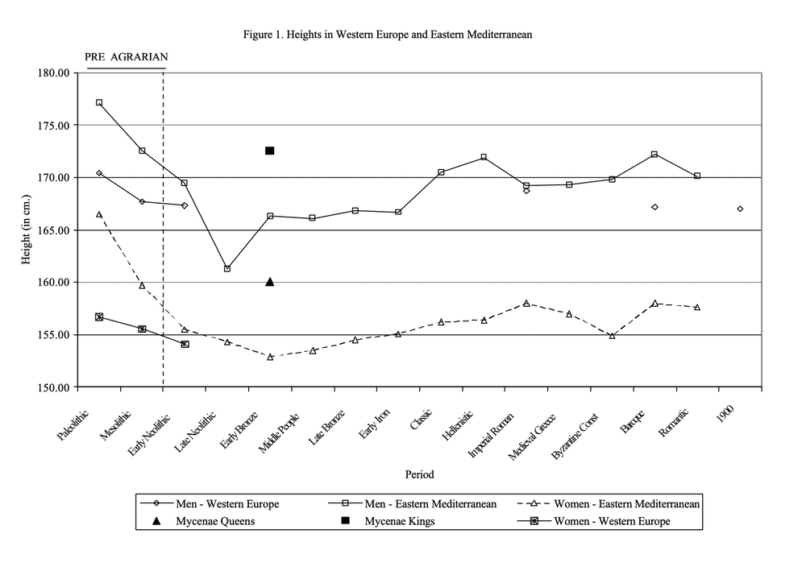

Male skeletal heights declined after the Neolithic transition. Source: Based on Angel (1984); Steckel (2008).

The height decline is consistent with the emergence of extractive hierarchies.

## The Mechanism: Surplus → Hierarchy

### Lecture 4

```
%%{init: {'theme': 'base', 'themeVariables': {'fontSize': '22px', 'primaryColor': '#4a7c6f', 'primaryTextColor': '#1e293b', 'primaryBorderColor': '#334155', 'lineColor': '#334155', 'secondaryColor': '#f9fafb', 'tertiaryColor': '#f9fafb'}, 'flowchart': {'useMaxWidth': true, 'nodeSpacing': 50, 'rankSp…
flowchart LR
    A["<b>SURPLUS</b><br/>Storage &amp;<br/>accumulation"] --> B["<b>SPECIALIZATION</b><br/>Division of labor<br/>&amp; new roles"]
    B --> C["<b>HIERARCHY</b><br/>Elites emerge<br/>&amp; unequal power"]
    C --> D["<b>INSTITUTIONS</b><br/>Property rights<br/>&amp; political order"]
    D -->|"Feedback: institutions<br/>stabilize extraction"| A

    style A fill:#4a7c6f,color:#f9fafb,stroke:#334155
    style B fill:#4a7c6f,color:#f9fafb,stroke:#334155
    style C fill:#b44527,color:#f9fafb,stroke:#334155
    style D fill:#b44527,color:#f9fafb,stroke:#334155
```

Source: Author’s illustration based on Harari (2015) and Acemoglu & Robinson (2012).

Replace “grain” with **data and attention**, and this is a diagram of the platform economy. Who controls the surplus controls the rest.

## The Losers Fight Back: Polanyi’s Pattern

### Lecture 2

When markets commodify things not produced for sale — land, labor, attention — society pushes back. Every era replays the cycle:

Recurrent Polanyian dynamics across technological eras. Source: Author’s illustration.

| Era | Technology | Fictitious Commodity | Counter-Movement |
| --- | --- | --- | --- |
| Agricultural | Enclosure | Land | Poor Laws |
| Industrial | Factory system | Labor | Labor rights |
| Digital | Platforms | Attention | Privacy/safety regulation |
| Emerging | AI | Cognition/identity | ? |

## Why Do the Powerful Ever Concede?

### Lecture 8

Elites didn’t reform out of goodwill — the costs of *not* reforming became too high.

- **Threat:** Luddism, Chartism, food riots — revolution was not hypothetical (France 1789, 1830, 1848)
- **Organization:** Unions gave workers collective power that individual bargaining never could
- **Elections:** Reform Acts (1832, 1867) forced politicians to answer to working-class voters

# Idea 3 — Rising Productivity ≠ Rising Wages

*Who captures the gains is a political question, not a technical one.*

## Engels’ Pause: Who Got the Growth

### Lecture 8

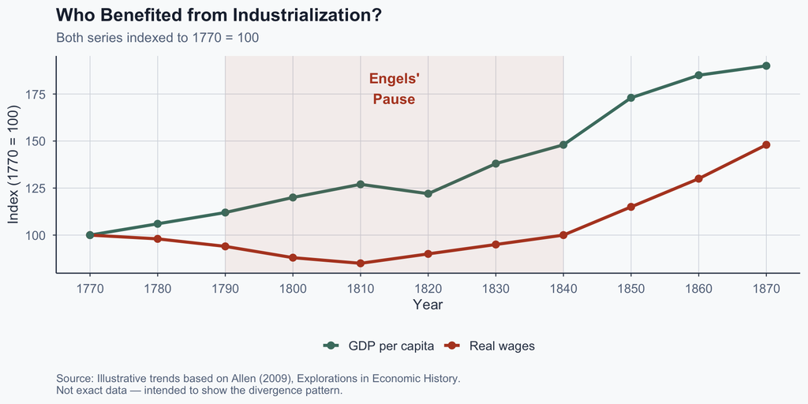

Figure 1: Real wages lagged GDP per capita for decades

After 10,000 flat years, growth finally exploded — and **for fifty years workers got none of it**. Now look at the next slide carefully.

## The Same Chart, Two Centuries Later

### Lecture 15

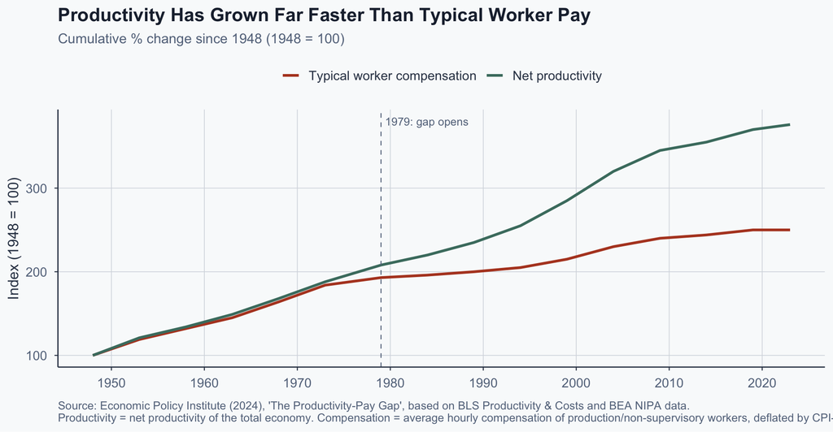

Figure 2

## Why Sharing Fails: The Bandwagon’s Two Conditions

### Lecture 15

Wages rise with productivity **only if two things are true** (Acemoglu & Johnson, 2023):

1. **The technology still needs workers** — it helps them, not replaces them
2. **Workers have the power to demand a share** — unions, tight labor markets, a vote

**If either fails, productivity rises but wages don’t.** That is the chart you just saw.

## History’s Warning — and Its Hope

### Lecture 15

**Why the bandwagon broke (Britain, 1790–1840):**

- Machinery *substituted* for artisans (Condition 1 failed)
- Unions illegal, no vote, surplus rural labor (Condition 2 failed)
- **Result**: productivity gains went to industrialists for half a century

**Why it eventually worked — deliberate institutional change:**

- Trade unions legalized (1824, 1871)
- Mass public schooling (Forster Act 1870)
- Suffrage extended (1867, 1884)

# Idea 4 — Inventions Appear Where They Pay

*…not where people are smartest — and each one seeds the next.*

## What Is a Technology, Anyway?

### Lecture 9

- A stick on the ground is just a stick
- Use it to lever a rock and it becomes a **technology**
- The stick didn’t change — so what did?

**Arthur’s answer:** a technology is nature *put to a purpose*. The invention isn’t the object — it’s the use.

And new technologies are built from old ones — so the more we have, the faster new ones appear.

**Even ChatGPT is a recombination**

ChatGPT feels brand-new, but its parts already existed:

- the **text** of the internet
- **chips** built for video games
- a decades-old **trick** — guessing the next word

The novelty was the **combination**, not the parts.

## So Why Didn’t Rome Industrialize?

### Lecture 3

Massive slavery → very cheap labor

Allen: cheap labor → low returns to labor-saving machinery

Scheidel estimates ~30-40% of Italy’s population enslaved at peak

**Why build a water mill when slaves grind grain cheaply?**

Rome had the engineering talent — aqueducts, concrete, roads. What it lacked was the **incentive**.

## …And Why Britain Did

### Lecture 8

### Empire → high wages → incentive to mechanize

- Same spinning jenny: **2–3%** return elsewhere, **30–40%** in Britain
- The knowledge existed everywhere — only Britain’s wages made it pay

> “The Industrial Revolution was the knock-on effect of British imperialism.” — Robert C. Allen

**Rome and Britain: one theory, opposite directions** — cheap labor kills mechanization, expensive labor demands it.

# Idea 5 — You Can’t Predict the Future, But You Can Analyze It

*The tools you leave with work on technologies that don’t exist yet.*

## The Tool: Think in Tasks, Not Jobs

### Lecture 11

**Key Insight**

Jobs are **bundles of tasks**. Technology affects tasks, not jobs directly.

```
┌────────────────────────────────────────────────────────┐
│                    JOB DECOMPOSITION                   │
│                                                        │
│    "Accountant" = { data entry, analysis, client       │
│                     communication, judgment calls }    │
│                                                        │
│    Automation affects these tasks differentially:      │
│    • Data entry: HIGH substitution potential           │
│    • Analysis: PARTIAL augmentation                    │
│    • Communication: LOW substitution potential         │
│    • Judgment: VERY LOW substitution potential         │
└────────────────────────────────────────────────────────┘
```

Three forces follow: **displacement (−), productivity (+), reinstatement (+)**. The net effect is not predetermined (Acemoglu & Restrepo, 2019).

## Why This Tool Matters: 47% → 9%

### Lecture 11

**Frey & Osborne (2017):** *“47% of U.S. jobs at high risk of automation.”*

- They scored **whole jobs** — but a nurse gives injections (automatable) *and* comforts patients (not). One task isn’t the job.
- Redo it **task-by-task** and 47% collapses to **9%** (OECD; Arntz et al., 2016).

One tool — task decomposition — deflated the scariest headline of the decade. **That is what this course trained you to do.**

## The Direction of AI Is a Choice

### Lecture 15

AI can be built to **replace** people — or to **help** them do more. Same technology, two directions (Acemoglu & Johnson, 2023).

- Today’s incentives push toward **replacement** — it’s cheaper to automate a worker than to augment one
- But that’s a policy choice, not a law of nature — taxes, research funding, and worker voice can change it

**Will AI share the gains — or repeat the Engels Pause?**

# What to Take With You

## Five Ideas — Now With Receipts

[output not shown]

## Three Mistakes You Will Now Catch Others Making

### Lecture 1

**1. “Tech is destiny”** — *“AI will eliminate jobs.”* No: institutions decide.

**2. Correlation ≠ causation** — *“Social media and depression rose together.”* Find the mechanism.

**3. Ignoring distribution** — *“Technology benefits society.”* Which part of society?

You’ll hear all three for the rest of your life. **Now you can answer back.**

*Thank you.*

## Grading

The course in relation to grading:

- Contributions to Class 33%
- Mid-term 33%
- Final exam 33%

**Contributions to Class (Reminder)**

- Presentation, physical presence, and class participation
- Submit two questions based on the class readings via Canvas each week
- Quality of questions matters, not just submission